# Questionnaire Report for Coral leopard grouper

(MERA version 5.4.3)

Yudi Herdiana (yherdiana@wcs.org)

2019-11-26

# About this document

This is a prototype of an automatic report that documents how the user specified the operating model and their various justifications.

# Introduction

# Fishery Characteristics

## Longevity

| Answered |
| --- |
| Very short-lived (5 < maximum age < 7) |
| Short-lived (7 < maximum age < 10) |
| Moderate life span (10 < maximum age < 20) |
| Moderately long-lived (20 < maximum age < 40) |
| Long-lived (40 < maximum age < 80) |
| Very long-lived (80 < maximum age < 160) |

| Justification |
| --- |
| maximum age of leopard coral grouper in Saleh bay is 14-26 years (Agustina et al, 2018; Ferreira an Russ, 1994; Russ et al, 1998) |

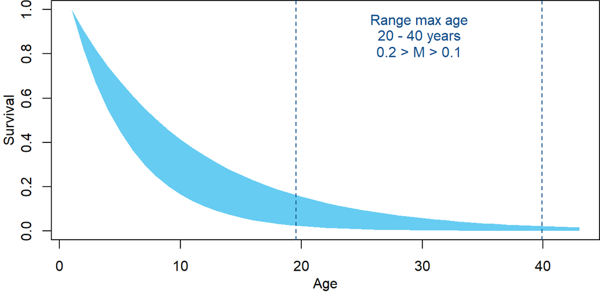

## Stock depletion

| Answered |
| --- |
| Crashed (D < 0.05) |
| Very depleted (0.05 < D < 0.1) |
| Depleted (0.1 < D < 0.15) |
| Moderately depleted (0.15 < D < 0.3) |
| Healthy (0.3 < D < 0.5) |
| Underexploited (0.5 < D) |

| Justification |
| --- |
| The stock of coral leopard grouper in Saleh Bay estimated at moderately depleted based on SPR estimation. The latest SPR estimation 0.24 (Agustina et al, 2018) |

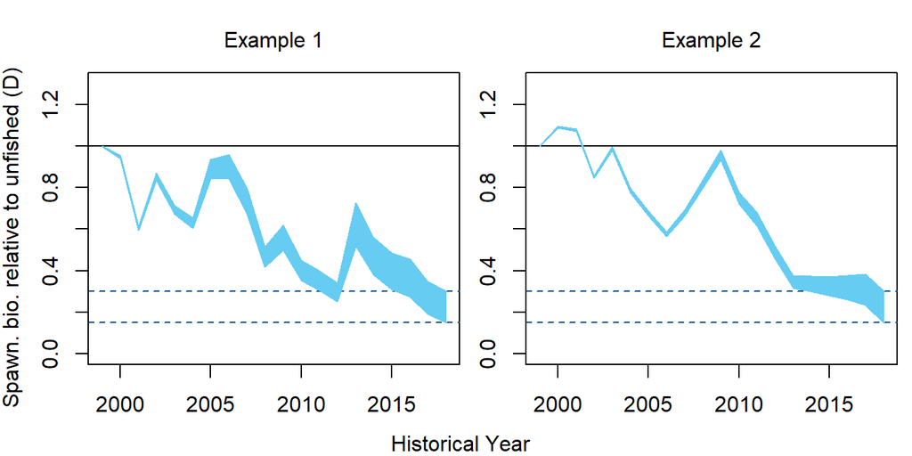

## Resilence

| Answered |
| --- |
| Not resilient (steepness < 0.3) |
| Low resilience (0.3 < steepness < 0.5) |
| Moderate resilence (0.5 < steepness < 0.7) |
| Resilient (0.7 < steepness < 0.9) |
| Very Resilient (0.9 < steepness) |

| Justification |
| --- |
| The resilience estimated by vulnerability rate. In Great Barrier Reef, coral leopard grouper has moderate vulnerability (Currey et al, 2010) |

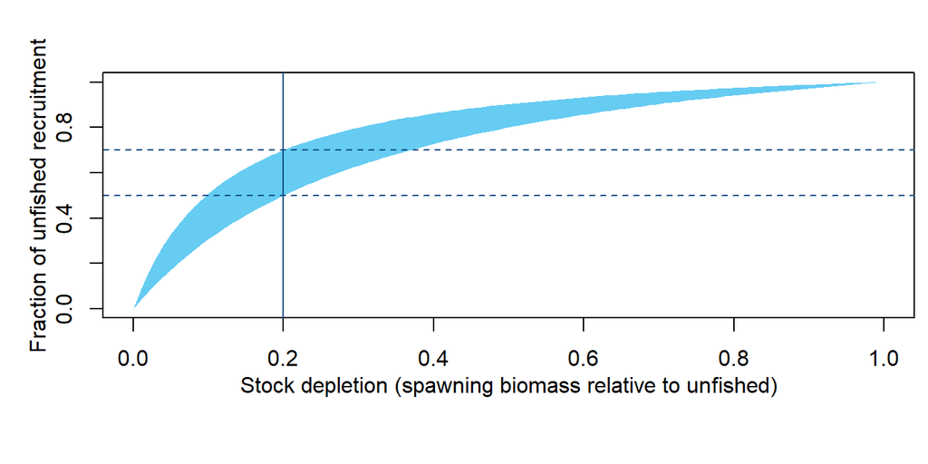

## Historical effort pattern

| Answered |
| --- |
| Stable |
| Two-phase |
| Boom-bust |
| Gradual increases |
| Stable, recent increases |
| Stable, recent declines |

| Justification |
| --- |
| Based on MMAF effort data for FMA 713 (2001-2011). |

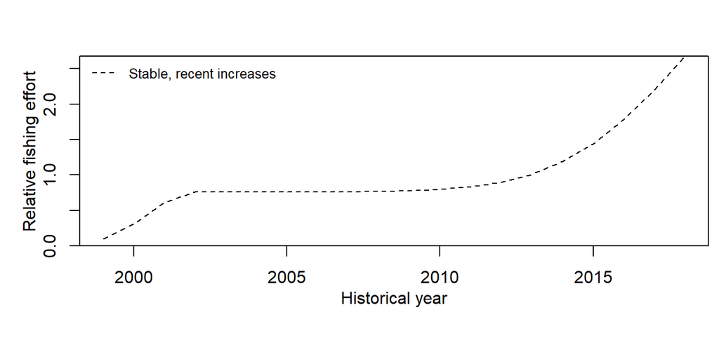

## Inter-annual variability in historical effort

| Answered |
| --- |
| Not variable (less than 20% inter-annual change (IAC)) |
| Variable (maximum IAC between 20% to 50%) |
| Highly variable (maximum IAC between 50% and 100%) |

| Justification |
| --- |
| Based on MMAF effort data for FMA 713 (2001-2011). The IAC estimated based on standard deviation of effort relative to mean effort. |

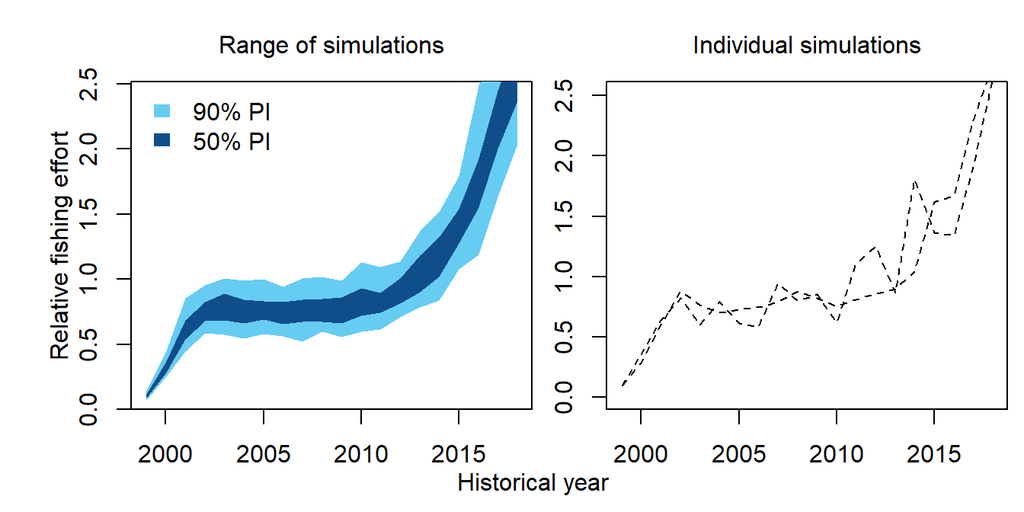

## Historical fishing efficiency changes

| Answered |
| --- |
| Declining by 2-3% pa (halves every 25-35 years) |
| Declining by 1-2% pa (halves every 35-70 years) |
| Stable -1% to 1% pa (may halve/double every 70 years) |
| Increasing by 1-2% pa (doubles every 35-70 years) |
| Increasing by 2-3% pa (doubles every 25-35 years) |

| Justification |
| --- |
| CPUE increasing with the equation : y = 0.0355x + 0.5336. |

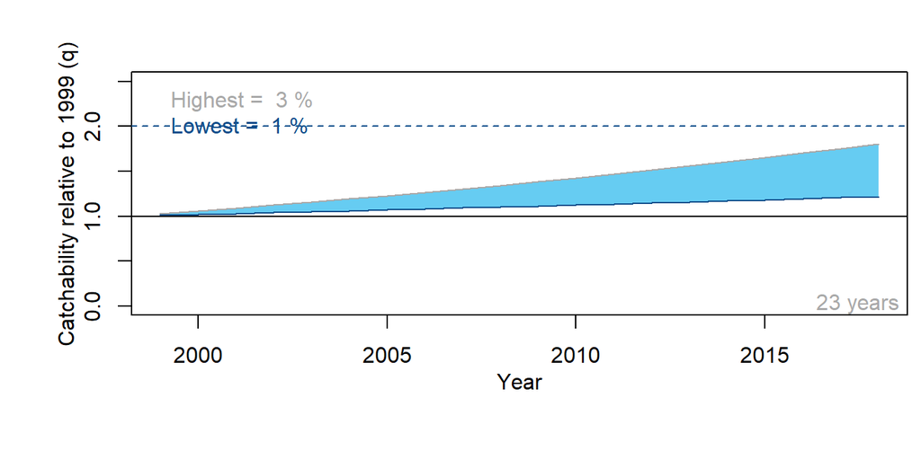

## Future fishing efficiency changes

| Answered |
| --- |
| Declining by 2-3% pa (halves every 25-35 years) |
| Declining by 1-2% pa (halves every 35-70 years) |
| Stable -1% to 1% pa (may halve/double every 70 years) |
| Increasing by 1-2% pa (doubles every 35-70 years) |
| Increasing by 2-3% pa (doubles every 25-35 years) |

| Justification |
| --- |
| With the assumption that the existing grouper fisheries management plan in Saleh Bay will improve the SPR with expected to increase catch. |

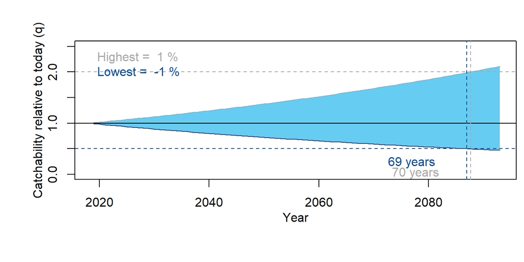

## Length at maturity

| Answered |
| --- |
| Very small (0.4 < LM < 0.5) |
| Small (0.5 < LM < 0.6) |
| Moderate (0.6 < LM < 0.7) |
| Moderate to large (0.7 < LM < 0.8) |
| Large (0.8 < LM < 0.9) |

| Justification |
| --- |
| Lm = 31.56-47.78 cm; Linf = 71.9 cm. (Agustina et al, 2018; Ferreira an Russ, 1994; Russ etbal, 1998; Khasanah et al, 2019) |

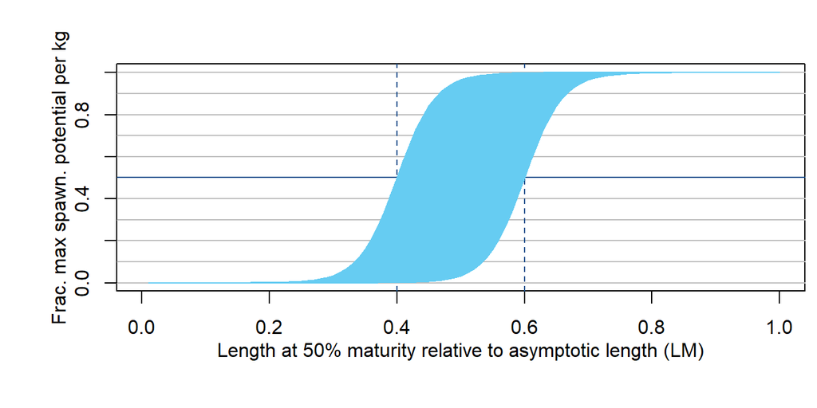

## Selectivity of small fish

| Answered |
| --- |
| Very small (0.1 < S < 0.2) |
| Small (0.2 < S < 0.4) |
| Half asymptotic length (0.4 < S < 0.6) |
| Large (0.6 < S < 0.8) |
| Very large (0.8 < S < 0.9) |

| Justification |
| --- |
| SL50 = 28.5 - 29.82 cm ; Linf = 71.9 cm. (Halim et al, 2018; Agustina et al, 2019) |

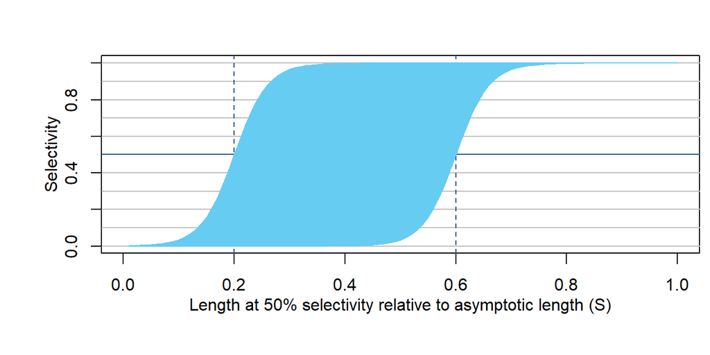

## Selectivity of large fish

| Answered |
| --- |
| Asymptotic selectivity (SL = 1) |
| Declining selectivity with length (0.75 < SL < 1) |
| Dome-shaped selectivity (0.25 < SL < 0.75) |
| Strong dome-shaped selectivity (SL < 0.25) |

| Justification |
| --- |
| No justification was provided |

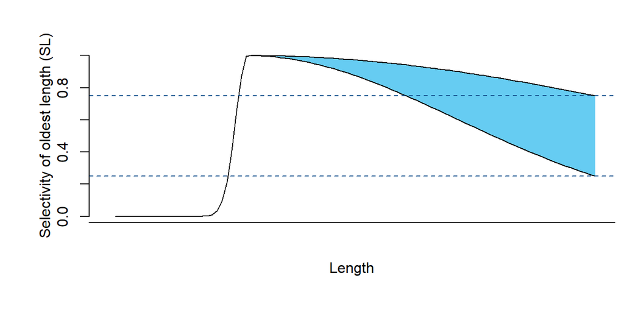

## Discard rate

| Answered |
| --- |
| Low (DR < 1%) |
| Low - moderate (1% < DR < 10%) |
| Moderate (10% < DR < 30%) |
| Moderate - high (30% < DR < 50%) |
| High (50% < DR < 70%) |

| Justification |
| --- |
| Coral leopard grouper dominated catch by speargun (50%) |

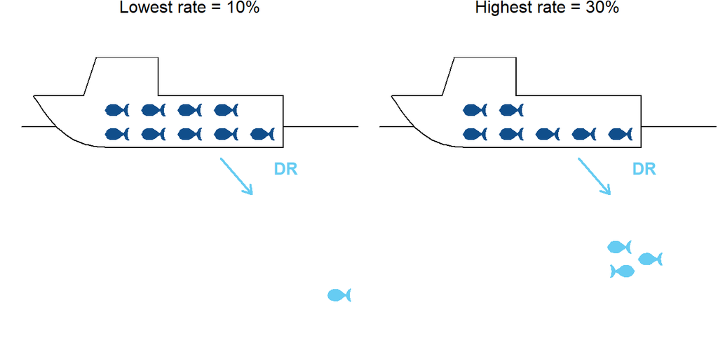

## Post-release mortality rate

| Answered |
| --- |
| Low (PRM < 5%) |
| Low - moderate (5% < PRM < 25%) |
| Moderate (25% < PRM < 50%) |
| Moderate - high (50% < PRM < 75%) |
| High (75% < PRM < 95%) |
| Almost all die (95% < PRM < 100%) |

| Justification |
| --- |
| No justification was provided |

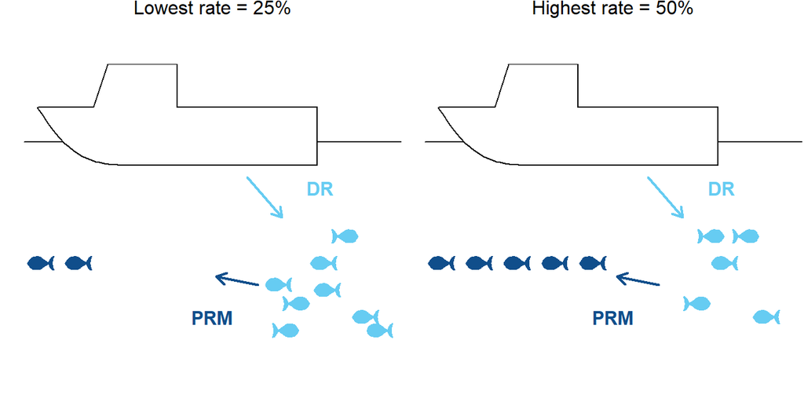

## Recruitment variability

| Answered |
| --- |
| Very low (less than 20% inter-annual changes (IAC)) |
| Low (max IAC of between 20% and 60%) |
| Moderate (max IAC of between 60% and 120%) |
| High (max IAC of between 120% and 180%) |
| Very high (max IAC greater than 180%) |

| Justification |
| --- |
| No justification was provided |

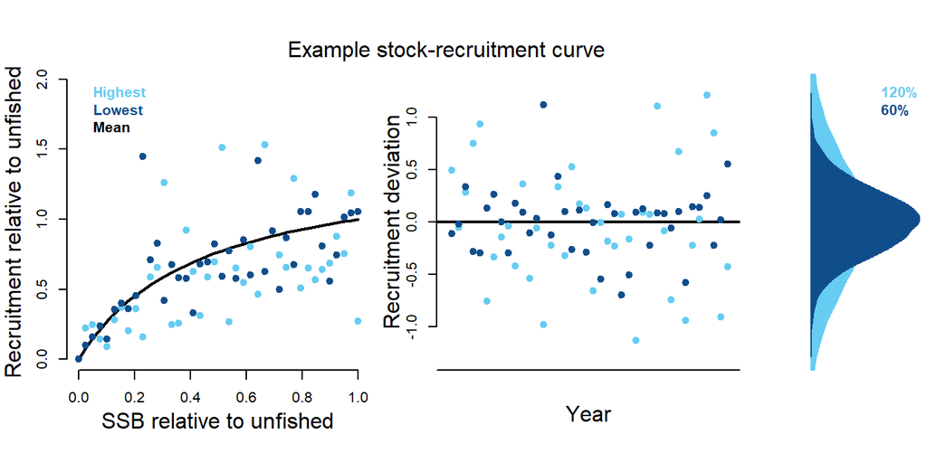

## Size of an existing MPA

| Answered |
| --- |
| None |
| Small (A < 5%) |
| Small-moderate (5% < A < 10%) |
| Moderate (10% < A < 20%) |
| Large (20% < A < 30%) |
| Very large (30% < A < 40%) |
| Huge (40% < A < 50%) |

| Justification |
| --- |
| No justification was provided |

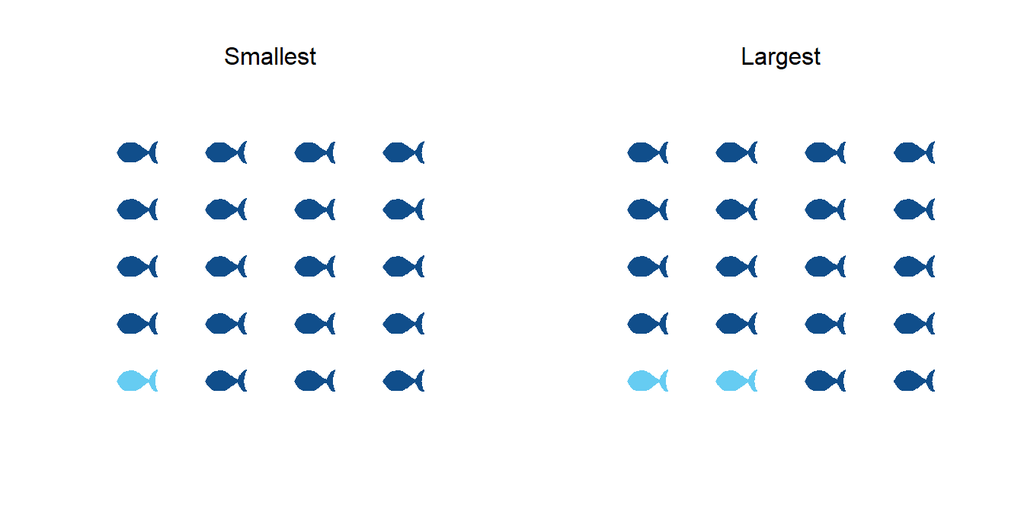

## Spatial mixing (movement) in/out of existing MPA

| Answered |
| --- |
| Very low (P < 1%) |
| Low (1% < P < 5%) |
| Moderate (5% < P < 10%) |
| High (10% < P < 20%) |
| Fully mixed |

| Justification |
| --- |
| As a reef-associated species, mixing should be low |

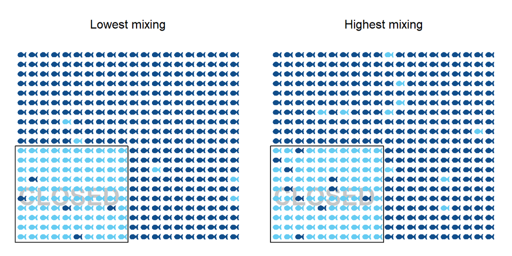

## Size of a future potential MPA

| Answered |
| --- |
| None |
| Small (A < 5%) |
| Small-moderate (5% < A < 10%) |
| Moderate (10% < A < 20%) |
| Large (20% < A < 30%) |
| Very large (30% < A < 40%) |
| Huge (40% < A < 50%) |

| Justification |
| --- |
| The change of the MPA have been discussed |

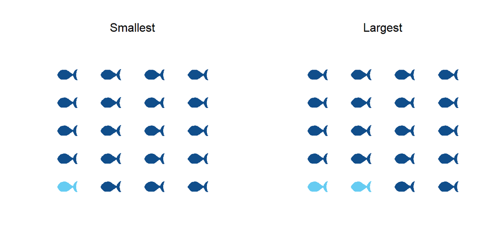

## Spatial mixing (movement) in/out of future potential MPA

| Answered |
| --- |
| Very low (P < 1%) |
| Low (1% < P < 5%) |
| Moderate (5% < P < 10%) |
| High (10% < P < 20%) |
| Fully mixed |

| Justification |
| --- |
| As a reef assosiated, mixing should be quite low |

[figure not shown]

## Initial stock depletion

| Answered |
| --- |
| Very low (0.1 < D1 < 0.15) |
| Low (0.15 < D1 < 0.3) |
| Moderate (0.3 < D < 0.5) |
| High (0.5 < D1) |
| Asymptotic unfished levels (D1 = 1) |

| Justification |
| --- |
| No justification was provided |

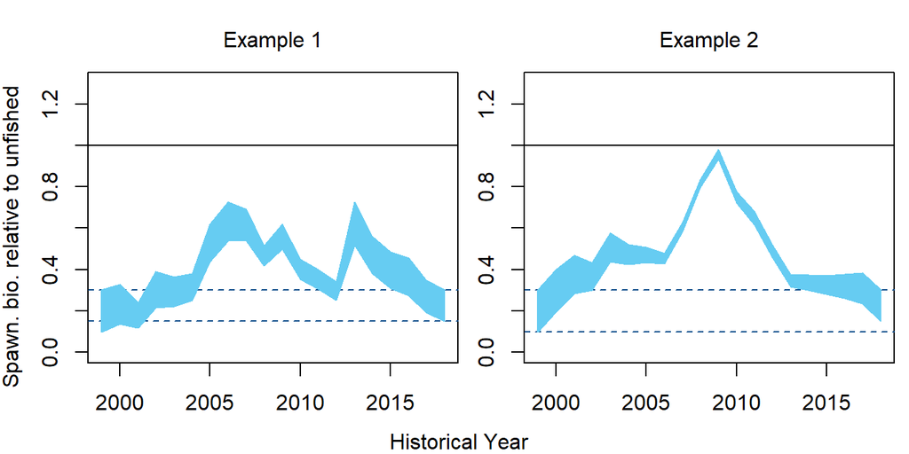

# Management Characteristics

## Types of fishery management that are possible

| Answered |
| --- |
| TAC (Total Allowable Catch): a catch limit |
| TAE (Total Allowable Effort): an effort limit |
| Size limit |
| Time-area closures (a marine reserve) |

Justification

1. Describe what, if any, current management measures are used to constrain catch/effort.  
-Size limit - Minimum catch size = 500 gr in Saleh Bay (Governor Decree No. 32/2018; DKP (2018)  
Collectors and traders are prohibited from buying fish < 500gr  
size, catch and effort limits, temporal closures, gear and vessel restrictions, and limited-entry licensing  
-Prohibition to catch in MPA’s no-take zones Governor Decree No. 32/2018; DKP (2018)  
Marine Protected Areas (MPAs), seasonal protection from fishing during spawning, or, ideally, the combination of those management approaches (Sadovy et al, 2013)  
-  
2. Describe historical management measures, if any.  
Sustainable grouper and snapper fisheries management action plan listed in Governor Decree No. 32/2018. The regulations, designed to rebuild declining fish stocks, include: size limit, control of fishing gear (gillnet mesh size > 4 inch, hook size for line fishing > number 4), prohibition to catch in MPA no take-zones, prohibition to use coral in trap fishing, prohibition to use of destructive fishing practice (dynamite, cyanide, hookah compressor).  
3. Describe main strengths and weaknesses of current monitoring and enforcement capacity.  
- there are Grouper and Snapper fisheries management committee, WNT to monitoring and evaluate the regulation  
4. Describe and reference any legal/policy requirements for management, monitoring and enforcement.  
Governor Decree No. 32/2018

## TAC offset: consistent overages/underages

| Answered |
| --- |
| Large underages (40% - 70% of recommended) |
| Underages (70% - 90% of recommended) |
| Slight underages (90% - 100% of recommended) |
| Taken exactly (95% - 105% of recommended) |
| Slight overages (100% - 110% of recommended) |
| Overages (110% - 150% of recommended) |
| Large overages (150% - 200% of recommended) |

| Justification |
| --- |
| No TAC regulation |

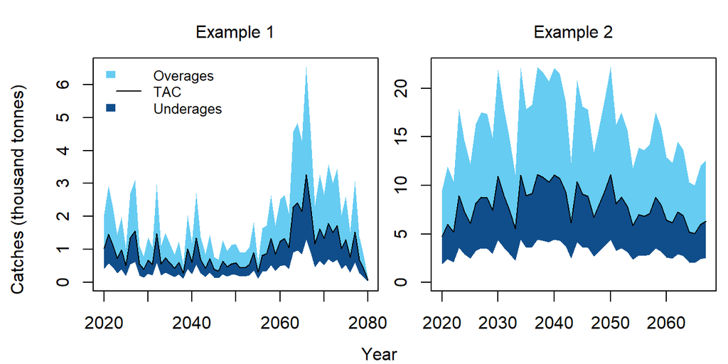

## TAC implementation variability

| Answered |
| --- |
| Constant (V < 1%) |
| Not variable (1% < V < 5%) |
| Low variability (5% < V < 10%) |
| Variable (10% < V < 20%) |
| Highly variable (20% < V < 40%) |

| Justification |
| --- |
| No TAC regulation |

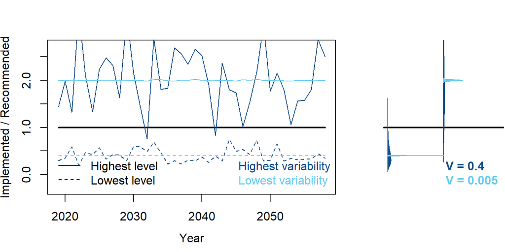

## TAE offset: consistent overages/underages

| Answered |
| --- |
| Large underages (40% - 70% of recommended) |
| Underages (70% - 90% of recommended) |
| Slight underages (90% - 100% of recommended) |
| Taken exactly (95% - 105% of recommended) |
| Slight overages (100% - 110% of recommended) |
| Overages (110% - 150% of recommended) |
| Large overages (150% - 200% of recommended) |

| Justification |
| --- |
| No TAE regulation |

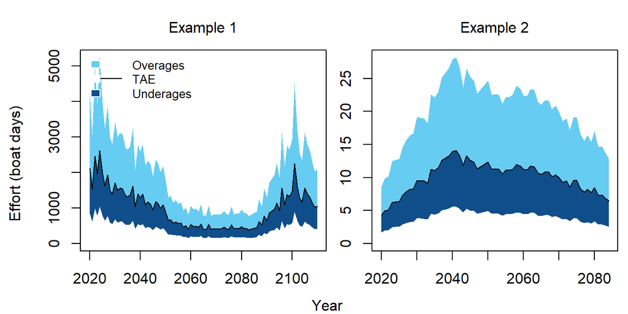

## TAE implementation variability

| Answered |
| --- |
| Constant (V < 1%) |
| Not variable (1% < V < 5%) |
| Low variability (5% < V < 10%) |
| Variable (10% < V < 20%) |
| Highly variable (20% < V < 40%) |

| Justification |
| --- |
| No TAE regulation |

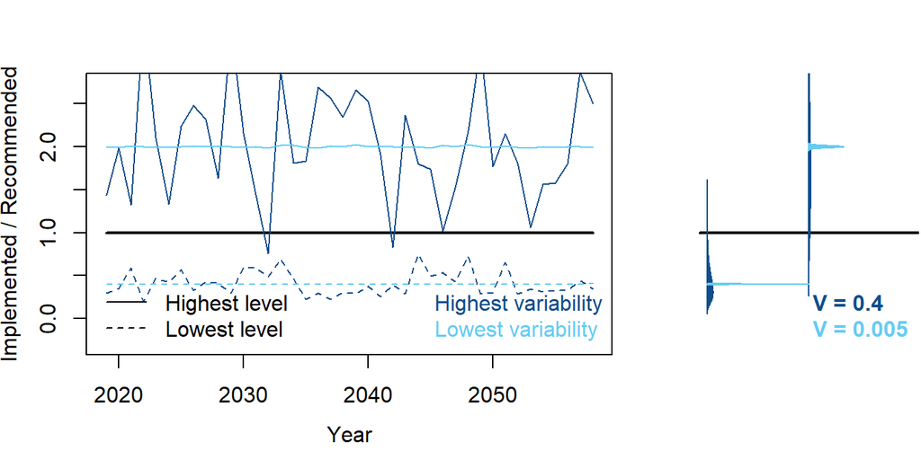

## Size limit offset: consistent overages/underages

| Answered |
| --- |
| Much smaller (40% - 70% of recommended) |
| Smaller (70% - 90% of recommended) |
| Slightly smaller (90% - 100% of recommended) |
| Taken exactly (95% - 105% of recommended) |
| Slightly larger (100% - 110% of recommended) |
| Larger (110% - 150% of recommended) |
| Much larger (150% - 200% of recommended) |

| Justification |
| --- |
| No justification was provided |

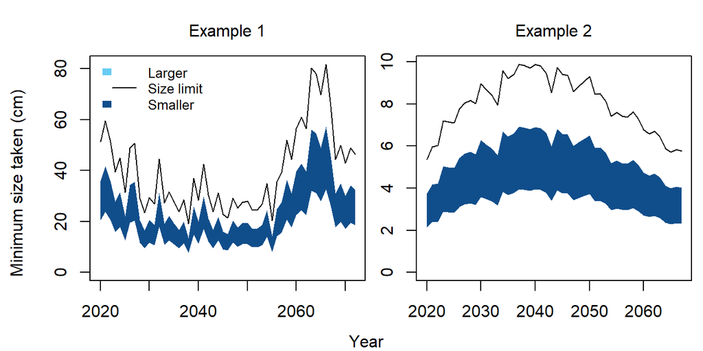

## Size limit implementation variability

| Answered |
| --- |
| Constant (V < 1%) |
| Not variable (1% < V < 5%) |
| Low variability (5% < V < 10%) |
| Variable (10% < V < 20%) |
| Highly variable (20% < V < 40%) |

| Justification |
| --- |
| change minimal catch length of the species from 20 cm to 22 cm with size limit 500 gram (31 cm), so the variability (V) in size limit implementation is 29% |

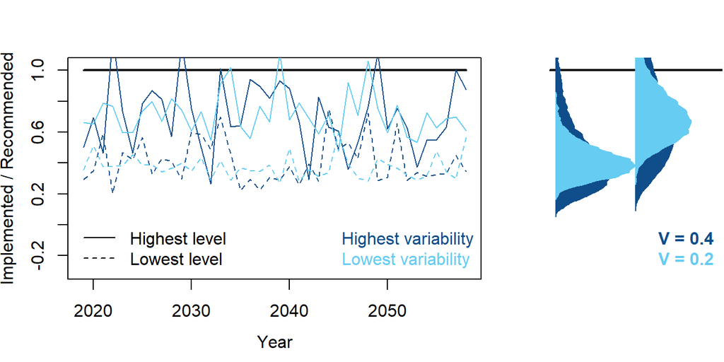

# Data Characteristics

## Available data types

| Answered |
| --- |
| Historical annual catches (from unfished) |
| Recent annual catches (at least 5 recent years) |
| Historical relative abundance index (from unfished) |
| Recent relative abundance index (at least 5 recent years) |
| Fishing effort |
| Size composition (length samples) |
| Age composition (age samples) |
| Growth (growth parameters) |
| Absolute biomass survey |

Justification

## Catch reporting bias

| Answered |
| --- |
| Strong under-reporting (30% - 50%) |
| Under-reporting (10% - 30%) |
| Slight under-reporting (0% - 10%) |
| Reported accurately (+/- 5%) |
| Slight over-reporting (less than 10%) |

| Justification |
| --- |
| No justification was provided |

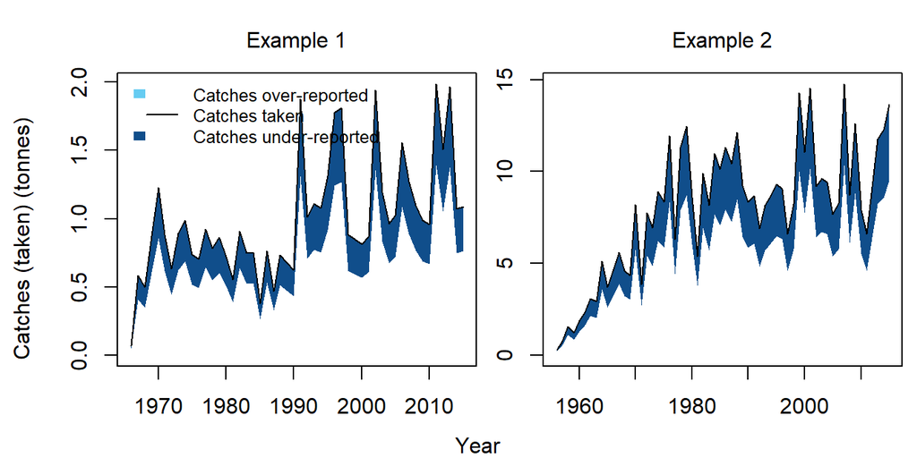

## Hyperstability in indices

| Answered |
| --- |
| Strong hyperdepletion (2 < Beta < 3) |
| Hyperdepletion (1.25 < Beta < 2) |
| Proportional (0.8 < Beta < 1.25) |
| Hyperstability (0.5 < Beta < 0.8) |
| Strong hyperstability (0.33 < Beta < 0.5) |

| Justification |
| --- |
| No justification was provided |

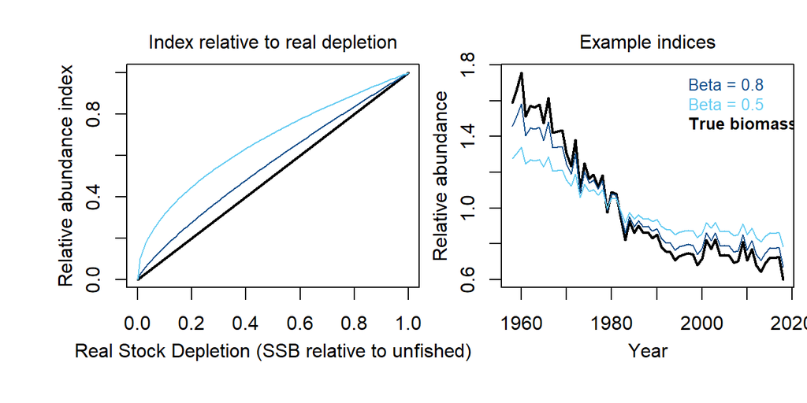

| Answered |
| --- |
| Perfect |
| Good (accurate and precise) |
| Data moderate (some what inaccurate and imprecise) |
| Data poor (inaccurate and imprecise) |

| Justification |
| --- |
| No justification was provided |

# Version Notes

The package is subject to ongoing testing. If you find a bug or a problem please send a report to t.carruthers@oceans.ubc.ca so that it can be fixed!

tcar_-2019-11-26-10:25:40

Open Source, GPL-2 2019